# Data Science for Veterinary Undergraduate Students

#### Summarising categorical variables

Creating summary statistics for categorical variables basically entails making counts of each observation, stratified by whatever columns we want to. Here we use breed distribution as an example. All we need to do is count the occurrences of breed along with the stratifying variables, then use complete and replace_na to fill in the implicit 0 numbers:

```r
topic_3_solution |>
  count(Herd, Selected, BreedText) |>
  complete(Herd, Selected, BreedText) |>
  replace_na(list(n = 0)) ->
  table1_breed
```

This gives us counts in a new column n:

```r
table1_breed
```

```
## # A tibble: 12 × 4
##    Herd   Selected BreedText     n
##    <chr>  <fct>    <chr>     <int>
##  1 Herd_A no       Holstein      0
##  2 Herd_A no       Jersey      430
##  3 Herd_A yes      Holstein      0
##  4 Herd_A yes      Jersey       50
##  5 Herd_B no       Holstein     85
##  6 Herd_B no       Jersey       25
##  7 Herd_B yes      Holstein     44
##  8 Herd_B yes      Jersey        6
##  9 Herd_C no       Holstein     33
## 10 Herd_C no       Jersey      127
## 11 Herd_C yes      Holstein      7
## 12 Herd_C yes      Jersey       43
```

Maybe it would be nice to add percentages in brackets. We can do this using group_by, mutate, str_c, and a couple of new functions sum and round, as follows:

```r
table1_breed |>
  group_by(Herd, Selected) |>
  mutate(totaln = sum(n)) |>
  ungroup() |>
  mutate(percent = round(n / totaln * 100, digits = 0)) |>
  mutate(text = str_c(n, " (", percent, "%)")) ->
  table1_breed
```

The sum function does what you would expect (summing the counts given by n), but notice that we use group_by before mutate so that the sum (“totaln”) is stratified by Herd and Selected. This allows us to calculate a percentage of each breed within this stratification by dividing n by totaln and multiplying by 100. We use the round function to give the percentage to the nearest whole number. Then we have a slightly complicated looking str_c function call, but this is really quite simple if you break it down - all it does is to paste together the following:

- n is the number of observations (created by count)
- ” (” is just text, meaning to put in a space and then an open bracket after the count
- percent is the (rounded) percentage that we just calculated
- “%)” means to finish off with a percentage symbol and a close bracket

Notice that we re-use the data fame name table1_breed at the start and end of the pipe chain; this means we over-write the data frame with the new one with extra columns:

```r
table1_breed
```

```
## # A tibble: 12 × 7
##    Herd   Selected BreedText     n totaln percent text
##    <chr>  <fct>    <chr>     <int>  <int>   <dbl> <chr>
##  1 Herd_A no       Holstein      0    430       0 0 (0%)
##  2 Herd_A no       Jersey      430    430     100 430 (100%)
##  3 Herd_A yes      Holstein      0     50       0 0 (0%)
##  4 Herd_A yes      Jersey       50     50     100 50 (100%)
##  5 Herd_B no       Holstein     85    110      77 85 (77%)
##  6 Herd_B no       Jersey       25    110      23 25 (23%)
##  7 Herd_B yes      Holstein     44     50      88 44 (88%)
##  8 Herd_B yes      Jersey        6     50      12 6 (12%)
##  9 Herd_C no       Holstein     33    160      21 33 (21%)
## 10 Herd_C no       Jersey      127    160      79 127 (79%)
## 11 Herd_C yes      Holstein      7     50      14 7 (14%)
## 12 Herd_C yes      Jersey       43     50      86 43 (86%)
```

The final step is to take the columns we need and make the data wide so that we have breeds in columns rather than rows:

```r
table1_breed |>
  select(Herd, BreedText, Selected, text) |>
  pivot_wider(names_from = BreedText, values_from = text) ->
  table1_breed
```

And we have our final result:

```r
table1_breed
```

```
## # A tibble: 6 × 4
##   Herd   Selected Holstein Jersey
##   <chr>  <fct>    <chr>    <chr>
## 1 Herd_A no       0 (0%)   430 (100%)
## 2 Herd_A yes      0 (0%)   50 (100%)
## 3 Herd_B no       85 (77%) 25 (23%)
## 4 Herd_B yes      44 (88%) 6 (12%)
## 5 Herd_C no       33 (21%) 127 (79%)
## 6 Herd_C yes      7 (14%)  43 (86%)
```

#### Summarising numeric variables

For numeric variables, we will typically want standard summary statistics in different columns. This could be any of the following:

- mean - using the mean function
- median - using the median function
- min or max - which are also functions in R
- variance - using the var function
- standard deviation - either using the sd function, or by using the sqrt function on a variance
- quantiles or quartiles - using the quantile function with probabilities given by the probs argument

In our case we only need mean and standard deviation of daily milk yield. To do this we first convert the yield per milking event into a daily yield by multiplying by the milking frequency, then use group_by and summarise to get the stratified summary statistics we need:

```r
topic_3_solution |>
  mutate(DailyYield = MilkYield * MilkFreq) |>
  group_by(Herd, Selected) |>
  summarise(MilkMean = mean(DailyYield), MilkSD = sd(DailyYield), .groups="drop") ->
  table1_milk
```

This gives us the following data frame:

```r
table1_milk
```

```
## # A tibble: 6 × 4
##   Herd   Selected MilkMean MilkSD
##   <chr>  <fct>       <dbl>  <dbl>
## 1 Herd_A no           25.7   6.06
## 2 Herd_A yes          24.9   5.80
## 3 Herd_B no           23.0   4.20
## 4 Herd_B yes          22.6   4.03
## 5 Herd_C no           23.7   6.75
## 6 Herd_C yes          24.8   6.77
```

However, these numbers are very precise, so we might want to round them for a publication output! We also need to make sure that we get a consistent number of decimal places, so for example if we round to 1 decimal place we want a yield of 23.042 to be shown as 23.0 and not 23. We do this using the round and format functions:

```r
table1_milk |>
  mutate(MilkMean = format(round(MilkMean, digits = 1))) |>
  mutate(MilkSD = format(round(MilkSD, digits = 1))) ->
  table1_milk

table1_milk
```

```
## # A tibble: 6 × 4
##   Herd   Selected MilkMean MilkSD
##   <chr>  <fct>    <chr>    <chr>
## 1 Herd_A no       25.7     6.1
## 2 Herd_A yes      24.9     5.8
## 3 Herd_B no       23.0     4.2
## 4 Herd_B yes      22.6     4.0
## 5 Herd_C no       23.7     6.8
## 6 Herd_C yes      24.8     6.8
```

This looks much better.

#### Combining sub-tables

We can now combine our two sub-tables into the overall table we need by joining on the stratifying variables:

```r
table1_breed |>
  left_join(
    table1_milk,
    by=c("Herd","Selected")
  ) ->
  table1
```

This gives us a publication-ready table:

```r
table1
```

```
## # A tibble: 6 × 6
##   Herd   Selected Holstein Jersey     MilkMean MilkSD
##   <chr>  <fct>    <chr>    <chr>      <chr>    <chr>
## 1 Herd_A no       0 (0%)   430 (100%) 25.7     6.1
## 2 Herd_A yes      0 (0%)   50 (100%)  24.9     5.8
## 3 Herd_B no       85 (77%) 25 (23%)   23.0     4.2
## 4 Herd_B yes      44 (88%) 6 (12%)    22.6     4.0
## 5 Herd_C no       33 (21%) 127 (79%)  23.7     6.8
## 6 Herd_C yes      7 (14%)  43 (86%)   24.8     6.8
```

But what happens if one of our co-authors wants the table arranged differently, i.e. summary statistics in rows and stratifying variables in columns? Remember that we can use pivot_longer and pivot_wider to re-shape tables however we want! This is usually easiest by converting the table into long format:

```r
table1 |>
  pivot_longer(cols = Holstein:MilkSD, names_to="Variable", values_to = "Statistic") ->
  table1_long

table1_long
```

```
## # A tibble: 24 × 4
##    Herd   Selected Variable Statistic
##    <chr>  <fct>    <chr>    <chr>
##  1 Herd_A no       Holstein 0 (0%)
##  2 Herd_A no       Jersey   430 (100%)
##  3 Herd_A no       MilkMean 25.7
##  4 Herd_A no       MilkSD   6.1
##  5 Herd_A yes      Holstein 0 (0%)
##  6 Herd_A yes      Jersey   50 (100%)
##  7 Herd_A yes      MilkMean 24.9
##  8 Herd_A yes      MilkSD   5.8
##  9 Herd_B no       Holstein 85 (77%)
## 10 Herd_B no       Jersey   25 (23%)
## # … with 14 more rows
```

And then using this long format to pivot back into a different wide format to what we started with. Sometimes we need to create new columns to combine different stratifying variables:

```r
table1_long |>
  mutate(Strata = case_when(
    Selected == "no" ~ str_c(Herd, " - not scored"),
    Selected == "yes" ~ str_c(Herd, " - selected for scoring"),
  )) |>
  select(Strata, Variable, Statistic) |>
  pivot_wider(names_from = Strata, values_from = Statistic)
```

```
## # A tibble: 4 × 7
##   Variable `Herd_A - not scored` Herd_A - sele…¹ Herd_…² Herd_…³ Herd_…⁴ Herd_…⁵
##   <chr>    <chr>                 <chr>           <chr>   <chr>   <chr>   <chr>
## 1 Holstein 0 (0%)                0 (0%)          85 (77… 44 (88… 33 (21… 7 (14%)
## 2 Jersey   430 (100%)            50 (100%)       25 (23… 6 (12%) 127 (7… 43 (86…
## 3 MilkMean 25.7                  24.9            23.0    22.6    23.7    24.8
## 4 MilkSD   6.1                   5.8             4.2     4.0     6.8     6.8
## # … with abbreviated variable names ¹`Herd_A - selected for scoring`,
## #   ²`Herd_B - not scored`, ³`Herd_B - selected for scoring`,
## #   ⁴`Herd_C - not scored`, ⁵`Herd_C - selected for scoring`
```

This method is so flexible that it allows you to achieve almost any table format you want to. The only thing you will need to do manually in Excel are to add formatting (e.g. bold) and tidy up column names (e.g. merging cells, splitting column names onto different rows).

### Exporting tables and data from R

There are a number of situations where we might want to export a data frame from R, and a number of different formats that we can use to do this. For example:

- Exporting a table for publication
- Exporting a data set to Excel or CSV, perhaps for a collaborator that doesn’t use R
- Exporting a data frame in a way that is easy to re-load into R, perhaps for a collaborator that doesn’t have the raw data

#### Exporting a table for publication

Let’s say that we want to copy-paste our table1 into a Word document containing a report or manuscript. We can’t copy the table directly from R very easily, so we need to go via an intermediate solution such as Excel. For this we will need to load the writexl package, and use the write_xlsx function:

```r
library("writexl")
write_xlsx(table1, path="table1.xlsx")
```

You will now have an Excel file called “table1.xlsx” saved in the working directory, containing the table we created.

The write_xlsx function can also save a file with multiple sheets, for example:

```r
write_xlsx(list(wide=table1, long=table1_long), path="table1.xlsx")
```

Notice that we are over-writing an existing file here - you should therefore be careful not to accidentally over-write a file that you have made changes in! Also note that the file cannot be open in another program (e.g. Excel) when it is being over-written; if you get an error when running this code then make sure Excel is not open and try again.

If you want to save time when opening the file, we can use the system function to automatically open the Excel file for us once it is created, like so:

```r
system("open table1.xlsx")
```

#### Exporting data to Excel and CSV

Exporting a dataset to Excel is just like exporting a table to Excel, as shown above. If you are sending data to somebody then it would be a good idea to include description sheets. You can even create these as data frames directly in R using the tribble function and then save them using write_xlsx if you want to:

```r
metadata <- tribble(
  ~Field, ~Value,
  "Dataset", "Processed data on lameness in cattle, version 1.0",
  "Date", "2023-02-27",
  "Description", "An example dataset of lameness observations in dairy cattle, processed to join with registry data on milk yield",
  "Name", "Matt Denwood",
  "Email", "...@...",
  "Source", "Lameness observations were collected on farm visits, other data was extracted from Danish registries before the vists. Note: this is actually simulated data!",
  "Reference", "Carried out as part of my PhD on lameness in dairy cattle, funded by SEGES with grant number S6716245.  Note: supporting material for this training exercise can be found at https://www.costmodds.org/teaching/voc_data_science/topic1/"
)

metadata
```

```
## # A tibble: 7 × 2
##   Field       Value
##   <chr>       <chr>
## 1 Dataset     Processed data on lameness in cattle, version 1.0
## 2 Date        2023-02-27
## 3 Description An example dataset of lameness observations in dairy cattle, proc…
## 4 Name        Matt Denwood
## 5 Email       ...@...
## 6 Source      Lameness observations were collected on farm visits, other data w…
## 7 Reference   Carried out as part of my PhD on lameness in dairy cattle, funded…
```

```r
variables <- tribble(
  ~Variable, ~Type, ~Description,
  "CKR", "id", "a unique identifier for each cow in Denmark",
  "DOB", "date", "date of birth of the animal",
  "Breed", "category", "a code for the animal breed",
  "BreedText", "text", "the full name of the animal breed",
  "Selected", "category", "whether or not the animal was selected for gait scoring",
  "GaitScore", "category", "the gait score - a number from 0 to 4 (see gait_lookup sheet)",
  "Herd", "id", "a unique identifier for the farms visited",
  "CHR", "id", "a unique identifier for each farm in Denmark",
  "MilkFreq", "number", "the reported milking frequency",
  "VisitDate", "date", "the date of on-farm visit",
  "CalvingDate", "date", "date of calving",
  "Lactation", "number", "the lactation number of the cow for this calving (i.e. how many times she has given birth, including this time)",
  "LactationGroup", "category", "the lactation group of the cow:  1st, 2nd or later parity",
  "DaysInMilk", "number", "the number of days between calving and milk recording",
  "MilkYield", "number", "the recorded milk yield (in kg) from the animal at this milking event",
  "GaitDescription", "text", "a description of the gait score code"
)

variables
```

```
## # A tibble: 16 × 3
##    Variable        Type     Description
##    <chr>           <chr>    <chr>
##  1 CKR             id       a unique identifier for each cow in Denmark
##  2 DOB             date     date of birth of the animal
##  3 Breed           category a code for the animal breed
##  4 BreedText       text     the full name of the animal breed
##  5 Selected        category whether or not the animal was selected for gait sco…
##  6 GaitScore       category the gait score - a number from 0 to 4 (see gait_loo…
##  7 Herd            id       a unique identifier for the farms visited
##  8 CHR             id       a unique identifier for each farm in Denmark
##  9 MilkFreq        number   the reported milking frequency
## 10 VisitDate       date     the date of on-farm visit
## 11 CalvingDate     date     date of calving
## 12 Lactation       number   the lactation number of the cow for this calving (i…
## 13 LactationGroup  category the lactation group of the cow:  1st, 2nd or later …
## 14 DaysInMilk      number   the number of days between calving and milk recordi…
## 15 MilkYield       number   the recorded milk yield (in kg) from the animal at …
## 16 GaitDescription text     a description of the gait score code
```

```r
tables <- tribble(
  ~Table, ~Description,
  "processed_data", "cow-level information based on multiple sources including on-farm visits and registry data",
  "gait_lookup", "codes used to record gait scores"
)

tables
```

```
## # A tibble: 2 × 2
##   Table          Description
##   <chr>          <chr>
## 1 processed_data cow-level information based on multiple sources including on-f…
## 2 gait_lookup    codes used to record gait scores
```

```r
write_xlsx(list(metadata=metadata, tables=tables, variables=variables, processed_data=topic_3_solution, gait_lookup=gait_lookup), path="lameness_data.xlsx")
```

Sometimes you might want to export data in a more generic format that other software is able to understand more easily. In this case, CSV (comma-separated values) is a good choice. For this we use the write_csv function:

```r
write_csv(topic_3_solution, file="lameness_data.csv")
```

This creates a text file in CSV format with the data, that you can open in Excel or other statistical analysis software. However, if you have a computer in a Scandinavian locale then Excel won’t read the file properly because it is expecting a semi-colon separated file. In that case, you can try this code instead:

```r
write_csv2(topic_3_solution, file="lameness_data.csv")
```

If you have used Scandinavian characters such as å ø or æ then these might not be displayed correctly in Excel. If that happens to you, try the write_excel_csv or write_excel_csv2 functions - these functions add a Byte order mark to the data to tell Excel that the file is UTF-8 encoded, so should resolve these problems.

#### Exporting data for later use in R

Exporting data to Excel or CSV format will remove some of the information on column formats, for example factors and sometimes dates will be turned into text. If we want to save data without losing this information, we can use the save function:

```r
save(topic_3_solution, table1, file = "processed_lameness_data.rda")
```

This will save all of the variables and/or data frames we specify into the filename given by the file argument. We can then re-load the data using load:

```r
(load("processed_lameness_data.rda"))
```

```
## [1] "topic_3_solution" "table1"
```

Putting the extra parentheses () around the load function causes the names of the stored variables / data frames to be shown in the console, which can be handy if we forgot the names of what we saved!

The advantages of this approach compared to Excel or CSV formats are (1) the file format is smaller and the data saves/loads faster (and can be made even smaller and faster using the [qs package](https://github.com/traversc/qs)), and (2) the data is loaded in exactly the same format as it was saved. The only disadvantage is that the format is specific to R, i.e. it is NOT useful for sharing data with people that don’t use R!

### Plots

There are a number of different plotting systems used in R, but by far the most flexible is the ggplot system provided by the ggplot2 package (which is part of tidyverse). A complete overview of ggplot is outside the scope of this topic, but the basic principles are as follows.

#### Generating plots

We always start with the ggplot function, which takes two arguments:

1. The data frame we are working with - this should always be in long format for ggplot
2. The aesthetics of the plot - i.e. which columns go on the x and y axes, what should be used to stratify by colour, etc

The aesthetics must be created using the aes function. For example:

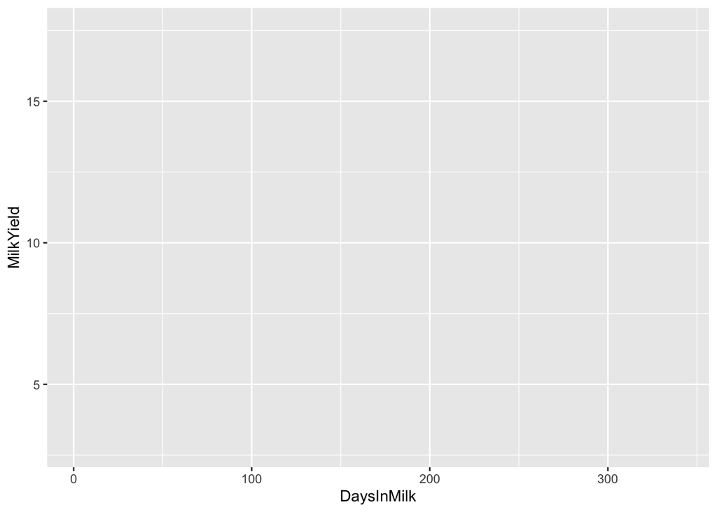

```r
ggplot(topic_3_solution, aes(x=DaysInMilk, y=MilkYield, col=Herd))
```

On its own this function only produces an empty plot: to do something interesting we need to add one or more layer. There are different types of plot layer depending on what we want to show with the plot, for example:

- geom_point for a basic scatterplot (x/y plot)
- geom_bar for a barchart
- geom_boxplot for a box plot
- geom_hist for a histogram
- stat_smooth for a smoothed line of best fit
- stat_ecdf for an empirical cumulative distribution function plot

There are many many other possibilities, but these cover the basics…

To add one or more layer we use the + symbol, and just like with pipe chains it is clearest to put each new layer on a new line:

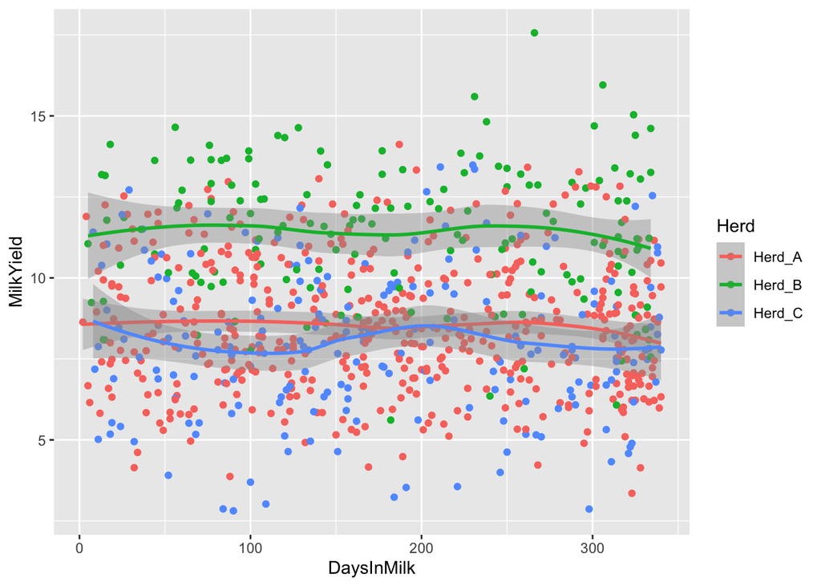

```r
ggplot(topic_3_solution, aes(x=DaysInMilk, y=MilkYield, col=Herd)) +
  geom_point() +
  stat_smooth()
```

Here is an example of a boxplot:

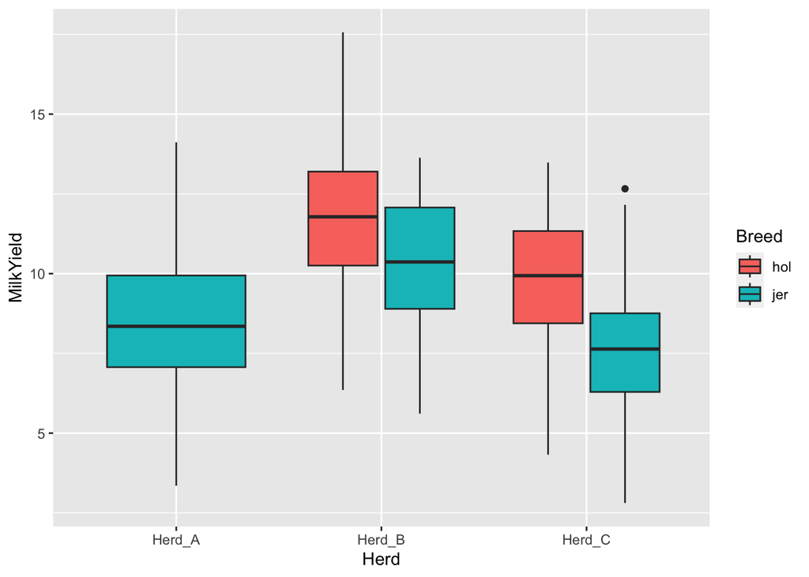

```r
ggplot(topic_3_solution, aes(x=Herd, y=MilkYield, fill=Breed)) +
  geom_boxplot()
```

This time we use fill rather than col, as we want a fill colour for the boxes rather than line/point colour.

Sometimes we need to do some pre-processing of a data frame to obtain the data we want to plot, for example:

- Filter only strata that we want to plot
- Filter out missing observations
- Change the data from wide to long format
- Summarise the data to counts by stratifying variables

For example:

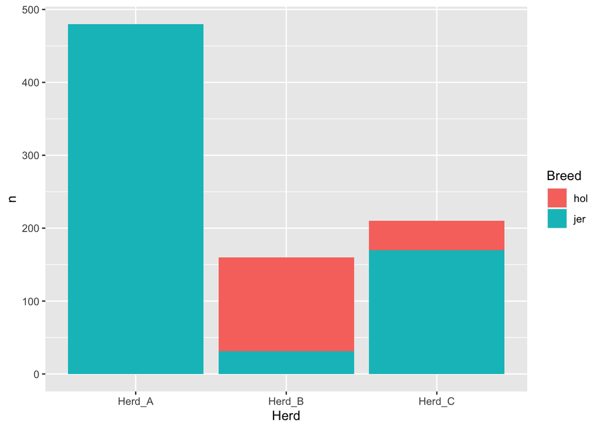

```r
topic_3_solution |>
  count(Herd, Breed) ->
  plotdata

ggplot(plotdata, aes(x=Herd, y=n, fill=Breed)) +
  geom_bar(stat="identity")
```

Note that when providing geom_bar with counts as we have done here, we need to specify the stat=“identify” argument. We can also tweak the plot to flip the axes, and change the position to “dodge” (from the default “stack”) so that the bars are shown next to each other:

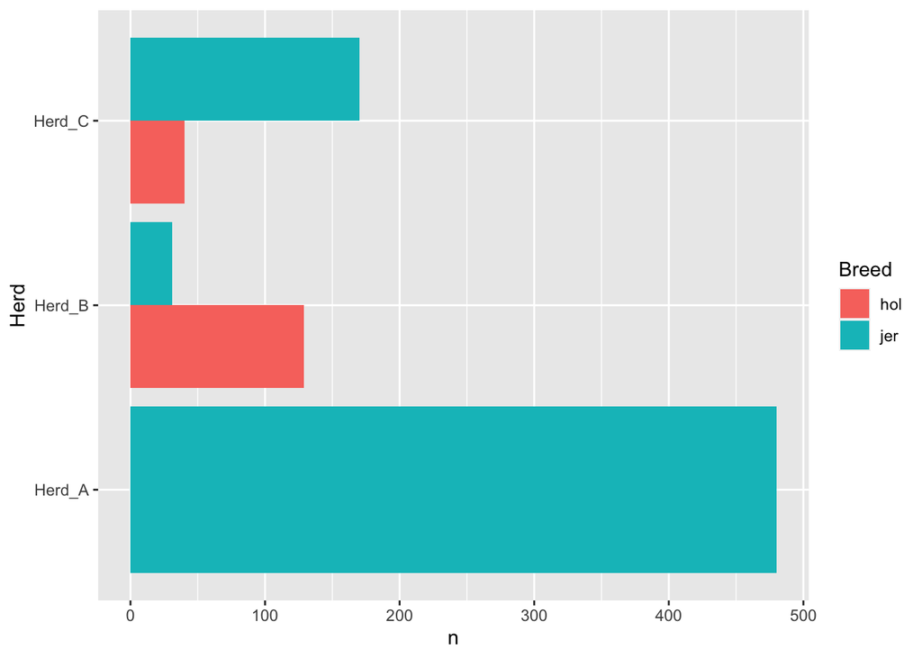

```r
ggplot(plotdata, aes(x=Herd, y=n, fill=Breed)) +
  geom_bar(stat="identity", position="dodge") +
  coord_flip()
```

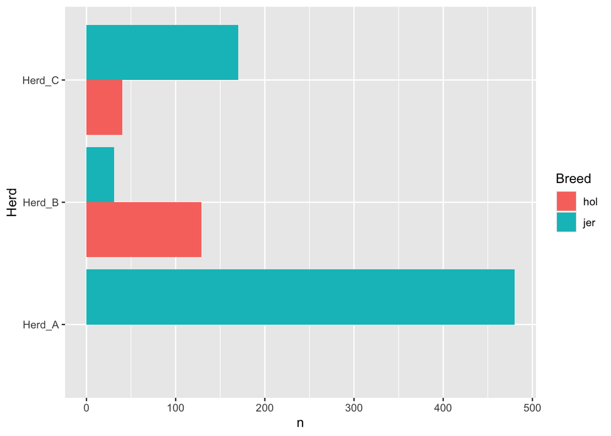

```r
topic_3_solution |>
  count(Herd, Breed) |>
  complete(Herd, Breed) |>
  replace_na(list(n=0)) ->
  plotdata

ggplot(plotdata, aes(x=Herd, y=n, fill=Breed)) +
  geom_bar(stat="identity", position="dodge") +
  coord_flip()
```

#### Saving plots

Once we have created a plot we like, we want to save it to a file for later use (e.g. inclusion in a report or manuscript). To do this, we first create a plot, then use the ggsave function with argument specifying the filename to use:

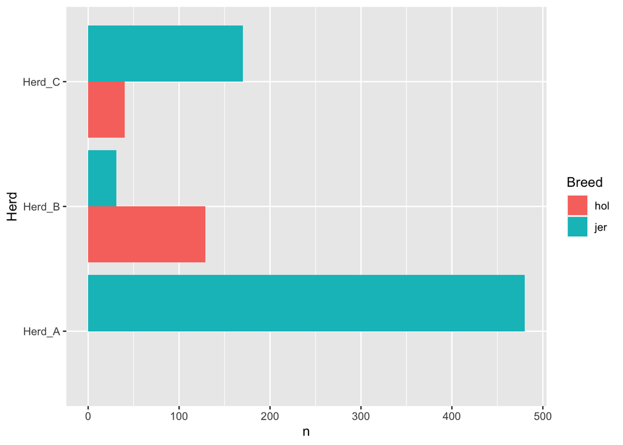

```r
ggplot(plotdata, aes(x=Herd, y=n, fill=Breed)) +
  geom_bar(stat="identity", position="dodge") +
  coord_flip()
```

```r
ggsave("figure1.pdf")
```

This creates a PDF containing our figure in the current working directory. Most of the time a PDF is what we want, but we can change this to e.g. jpeg by changing the file extension:

```r
ggsave("figure1.jpg", width=5, height=6)
```

Specifying width and height is optional, but allows us to perfect the size and aspect ratio for a publication.

Very occasionally you might want to combine multiple plots within the same figure. For this you can use the ggarrange function in the [ggpubr package](https://rpkgs.datanovia.com/ggpubr/).

#### More advanced plots

Here is another example:

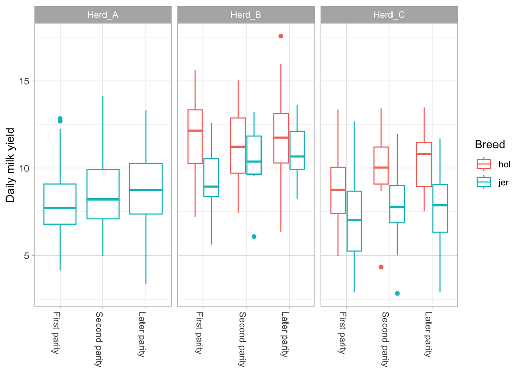

```r
ggplot(topic_3_solution, aes(x=LactationGroup, y=MilkYield, col=Breed)) +
  geom_boxplot() +
  facet_wrap(~ Herd) +
  ylab("Daily milk yield") +
  xlab(NULL) +
  theme_light() +
  theme(axis.text.x=element_text(angle = -90, hjust = 0))
```

This introduces a few more useful things that we have added to the plot:

We use facet_wrap (and the related facet_grid) quite frequently for generating plots with stratified variables, so that is worth remembering. The ylab and xlab options are also useful, particularly for removing a label where it isn’t needed. I almost always also use theme_light with my plots - if you prefer to have that as the default value then you can use this code at the top of your R script to ensure that every subsequently made plot uses this theme:

```r
theme_set(theme_light())
```

#### Getting help

There are a lot of other options to achieve specific things, like theme(axis.text.x=element_text(angle = -90, hjust = 0)) in the plot above. We will never be able to remember them all, but searching the internet for the thing you want to achieve may help. For example try to google “ggplot how to rotate axis text” and you will find an answer that can help (just like I did when I wrote this lesson!).

You can also find specific help with ggplot from online books like [the R graphics cookbook](http://www.cookbook-r.com/Graphs/) and the “Data visualisation” chapter of the excellent [R for Data Science book](https://r4ds.had.co.nz). It is a lot of work to get all the way through this book, but it is an extremely useful resource and is kept well updated by the authors (who are also the authors of the tidyverse package).

## Excercise

For this final exercise in the series, you should make the following table and plot:

Table 2: the number of animals with each gait score category per herd, excluding the animals not scored You should have 3 rows (Herd A, Herd B and Herd C) and 6 columns (Herd, Score 0, Score 1, Score 2, Score 3, Score 4). Save this along with table 1 (the table1 data frame we created above) in an Excel file.

Figure 1: a boxplot of daily milk yield on the y axis and gait score category on the x axis, excluding the animals without a gait score. Show the 3 herds in different sub-plots, arranged with 1 column and 3 rows, and invert the axes so that the boxplots are oriented horizontally rather than vertically. Save the figure as a PDF.

Remember to start by copy/pasting the code given above - it is always easier to modify working code to do what you need, rather than trying to write code from scratch!

### Solution

Click here to see a suggested solution (plus some explanation) for this exercise.

## Feedback and acknowledgements

If you have any feedback or suggestions on this training material then please consider filling out [our brief survey](https://forms.gle/KDtwsygjJdE2azBk8)

Development of this training material was partly funded by the [Veterinary Online Collection](https://veterinary-online-collection.eu).

[Return to home page](https://www.costmodds.org/teaching/voc_data_science/)